# Module R: Repetition

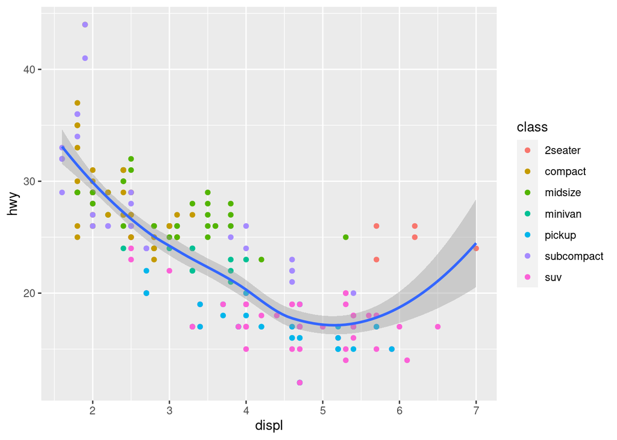

```r
mpg %>%
ggplot (aes (x = displ, y = hwy)) +

geom_point (aes (color = class))+
  geom_smooth()
```

**Exercise**

tweak the following code to make it run correctly

```r
library(palmerpenguins)
library(ggthemes)
ggplot(data = penguis, mapping = aes(x = body_mass_g, y = flipper_length_m)) +
  geom_point() +
  geom_smooth(method = "lm")
  scale_color_colorblind()
```

**Solution**

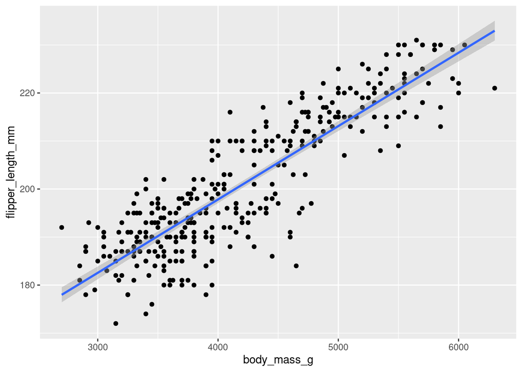

```r
library(palmerpenguins)
library(ggthemes)
ggplot(data = penguins, mapping = aes(x = body_mass_g, y = flipper_length_mm)) +
  geom_point() +
  geom_smooth(method = "lm") +
  scale_color_colorblind()
```

**Exercise**

Read the “environment.csv” file in the datasets folder (from the Beckerman book) and look at the data using glimpse(), and create a line graph of altitude.m and temperature.C

**Solution**

```r
environment <- read.csv("environment.csv")

library(dplyr)
glimpse(environment)
```

```
Rows: 10
Columns: 5
$ site             <int> 1, 2, 3, 4, 5, 6, 7, 8, 9, 10
$ altitude.m       <int> 13, 160, 100, 205, 45, 84, 349, 509, 399, 30
$ temperature.C    <int> 24, 18, 17, 15, 20, 21, 14, 11, 13, 19
$ rainfall.m       <dbl> 0.01, 0.50, 0.60, 1.10, 0.09, 0.20, 1.20, 0.60, 0.80,…
$ biomass.g.per.m2 <int> 20, 120, 110, 200, 45, 70, 150, 275, 220, 38
```

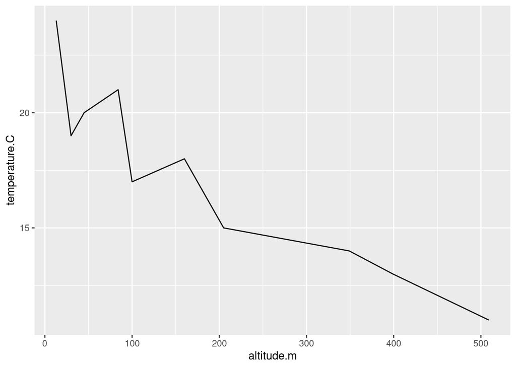

```r
library(ggplot2)
ggplot(environment, aes(x = altitude.m, y = temperature.C)) +
  geom_line()
```

# Repetition of Module 3

## Checkpoint 3.1

**Exercise**

Now rearrange the table from back to front and then delete column a and filter for rows with 12 in c - all in one pipe.

```r
testdat1 <- tibble(a = c("A", "B", "B", "B", "C"),
                   b = c(5, 4, 4, 2, 1),
                   c = c(12, 2, 3, 34, 12))
```

**Solution**

```r
testdat1 |>
  arrange(c,b,a) |>
  select(c,b) |>
  filter(c == 12)
```

```
# A tibble: 2 × 2
      c     b
  <dbl> <dbl>
1    12     1
2    12     5
```

**Exercise**

**Solution**

**Exercise**

```r
mtcars
```

```
                     mpg cyl  disp  hp drat    wt  qsec vs am gear carb
Mazda RX4           21.0   6 160.0 110 3.90 2.620 16.46  0  1    4    4
Mazda RX4 Wag       21.0   6 160.0 110 3.90 2.875 17.02  0  1    4    4
Datsun 710          22.8   4 108.0  93 3.85 2.320 18.61  1  1    4    1
Hornet 4 Drive      21.4   6 258.0 110 3.08 3.215 19.44  1  0    3    1
Hornet Sportabout   18.7   8 360.0 175 3.15 3.440 17.02  0  0    3    2
Valiant             18.1   6 225.0 105 2.76 3.460 20.22  1  0    3    1
Duster 360          14.3   8 360.0 245 3.21 3.570 15.84  0  0    3    4
Merc 240D           24.4   4 146.7  62 3.69 3.190 20.00  1  0    4    2
Merc 230            22.8   4 140.8  95 3.92 3.150 22.90  1  0    4    2
Merc 280            19.2   6 167.6 123 3.92 3.440 18.30  1  0    4    4
Merc 280C           17.8   6 167.6 123 3.92 3.440 18.90  1  0    4    4
Merc 450SE          16.4   8 275.8 180 3.07 4.070 17.40  0  0    3    3
Merc 450SL          17.3   8 275.8 180 3.07 3.730 17.60  0  0    3    3
Merc 450SLC         15.2   8 275.8 180 3.07 3.780 18.00  0  0    3    3
Cadillac Fleetwood  10.4   8 472.0 205 2.93 5.250 17.98  0  0    3    4
Lincoln Continental 10.4   8 460.0 215 3.00 5.424 17.82  0  0    3    4
Chrysler Imperial   14.7   8 440.0 230 3.23 5.345 17.42  0  0    3    4
Fiat 128            32.4   4  78.7  66 4.08 2.200 19.47  1  1    4    1
Honda Civic         30.4   4  75.7  52 4.93 1.615 18.52  1  1    4    2
Toyota Corolla      33.9   4  71.1  65 4.22 1.835 19.90  1  1    4    1
Toyota Corona       21.5   4 120.1  97 3.70 2.465 20.01  1  0    3    1
Dodge Challenger    15.5   8 318.0 150 2.76 3.520 16.87  0  0    3    2
AMC Javelin         15.2   8 304.0 150 3.15 3.435 17.30  0  0    3    2
Camaro Z28          13.3   8 350.0 245 3.73 3.840 15.41  0  0    3    4
Pontiac Firebird    19.2   8 400.0 175 3.08 3.845 17.05  0  0    3    2
Fiat X1-9           27.3   4  79.0  66 4.08 1.935 18.90  1  1    4    1
Porsche 914-2       26.0   4 120.3  91 4.43 2.140 16.70  0  1    5    2
Lotus Europa        30.4   4  95.1 113 3.77 1.513 16.90  1  1    5    2
Ford Pantera L      15.8   8 351.0 264 4.22 3.170 14.50  0  1    5    4
Ferrari Dino        19.7   6 145.0 175 3.62 2.770 15.50  0  1    5    6
Maserati Bora       15.0   8 301.0 335 3.54 3.570 14.60  0  1    5    8
Volvo 142E          21.4   4 121.0 109 4.11 2.780 18.60  1  1    4    2
```

```r
?mtcars

mtcars |>  arrange(mpg)
```

```
                     mpg cyl  disp  hp drat    wt  qsec vs am gear carb
Cadillac Fleetwood  10.4   8 472.0 205 2.93 5.250 17.98  0  0    3    4
Lincoln Continental 10.4   8 460.0 215 3.00 5.424 17.82  0  0    3    4
Camaro Z28          13.3   8 350.0 245 3.73 3.840 15.41  0  0    3    4
Duster 360          14.3   8 360.0 245 3.21 3.570 15.84  0  0    3    4
Chrysler Imperial   14.7   8 440.0 230 3.23 5.345 17.42  0  0    3    4
Maserati Bora       15.0   8 301.0 335 3.54 3.570 14.60  0  1    5    8
Merc 450SLC         15.2   8 275.8 180 3.07 3.780 18.00  0  0    3    3
AMC Javelin         15.2   8 304.0 150 3.15 3.435 17.30  0  0    3    2
Dodge Challenger    15.5   8 318.0 150 2.76 3.520 16.87  0  0    3    2
Ford Pantera L      15.8   8 351.0 264 4.22 3.170 14.50  0  1    5    4
Merc 450SE          16.4   8 275.8 180 3.07 4.070 17.40  0  0    3    3
Merc 450SL          17.3   8 275.8 180 3.07 3.730 17.60  0  0    3    3
Merc 280C           17.8   6 167.6 123 3.92 3.440 18.90  1  0    4    4
Valiant             18.1   6 225.0 105 2.76 3.460 20.22  1  0    3    1
Hornet Sportabout   18.7   8 360.0 175 3.15 3.440 17.02  0  0    3    2
Merc 280            19.2   6 167.6 123 3.92 3.440 18.30  1  0    4    4
Pontiac Firebird    19.2   8 400.0 175 3.08 3.845 17.05  0  0    3    2
Ferrari Dino        19.7   6 145.0 175 3.62 2.770 15.50  0  1    5    6
Mazda RX4           21.0   6 160.0 110 3.90 2.620 16.46  0  1    4    4
Mazda RX4 Wag       21.0   6 160.0 110 3.90 2.875 17.02  0  1    4    4
Hornet 4 Drive      21.4   6 258.0 110 3.08 3.215 19.44  1  0    3    1
Volvo 142E          21.4   4 121.0 109 4.11 2.780 18.60  1  1    4    2
Toyota Corona       21.5   4 120.1  97 3.70 2.465 20.01  1  0    3    1
Datsun 710          22.8   4 108.0  93 3.85 2.320 18.61  1  1    4    1
Merc 230            22.8   4 140.8  95 3.92 3.150 22.90  1  0    4    2
Merc 240D           24.4   4 146.7  62 3.69 3.190 20.00  1  0    4    2
Porsche 914-2       26.0   4 120.3  91 4.43 2.140 16.70  0  1    5    2
Fiat X1-9           27.3   4  79.0  66 4.08 1.935 18.90  1  1    4    1
Honda Civic         30.4   4  75.7  52 4.93 1.615 18.52  1  1    4    2
Lotus Europa        30.4   4  95.1 113 3.77 1.513 16.90  1  1    5    2
Fiat 128            32.4   4  78.7  66 4.08 2.200 19.47  1  1    4    1
Toyota Corolla      33.9   4  71.1  65 4.22 1.835 19.90  1  1    4    1
```

**Exercise**

Create a subset of the mtcars dataset that only contains data on mpg and wt.

**Solution**

```r
mtcars |> count(mpg, wt)
```

```
    mpg    wt n
1  10.4 5.250 1
2  10.4 5.424 1
3  13.3 3.840 1
4  14.3 3.570 1
5  14.7 5.345 1
6  15.0 3.570 1
7  15.2 3.435 1
8  15.2 3.780 1
9  15.5 3.520 1
10 15.8 3.170 1
11 16.4 4.070 1
12 17.3 3.730 1
13 17.8 3.440 1
14 18.1 3.460 1
```

[output cut: 18 more lines]

**Exercise**

MEAN OF SPEEDS PER DAY. Flights that departed from June 1 to 3 from NYC to Atlanta with departure delay of less than 1 hour, taking off after 8 am. Additional information: Speed in km/h instead of mph, each speed only mentioned once. 73 options found. No information on Carrier and Tail Number as well as air time through time_hour.

**Solution**

```r
library(nycflights13)
flights |>
  mutate(
    speed_kmh =distance / air_time * 60 *   1.61,
    .before = carrier
  ) |>
  filter(month == 6 & day %in% c(1:3)) |>
  filter(dest == "ATL") |>
  group_by(day) |>
  distinct(speed_kmh, .keep_all = T) |>
  filter(dep_delay < 60) |>
  arrange(dep_time < 0800) |>
  select(!carrier:tailnum & !air_time:time_hour)
```

```
# A tibble: 73 × 12
# Groups:   day [3]
    year month   day dep_time sched_dep_time dep_delay arr_time sched_arr_time
   <int> <int> <int>    <int>          <int>     <dbl>    <int>          <int>
 1  2013     6     1      852            855        -3     1106           1120
 2  2013     6     1      856            900        -4     1121           1139
 3  2013     6     1      857            900        -3     1106           1119
 4  2013     6     1      955           1000        -5     1216           1220
 5  2013     6     1      957           1000        -3     1235           1230
 6  2013     6     1     1143           1145        -2     1344           1400
 7  2013     6     1     1205           1205         0     1424           1425
 8  2013     6     1     1254           1300        -6     1506           1519
 9  2013     6     1     1356           1400        -4     1601           1630
10  2013     6     1     1454           1500        -6     1707           1732
# ℹ 63 more rows
# ℹ 4 more variables: arr_delay <dbl>, speed_kmh <dbl>, origin <chr>,
#   dest <chr>
```

**Exercise**

Create a data frame. The first column in is a vector with: Ga, Ka, Sa, Ka, Pa.The second column has: 5,7,9,3,6. The third column has: Za, Ba, Ma, Ba, Ta. Remove the duplicated values from the first and third columns. which one is kept. Why?

**Solution**

```r
data <- tibble (x=c("Ga","Ka","Sa","Ka","Pa"),
                y=c(5,7,9,3,6),
                z=c("Za","Ba","Ma","Ba","Ta"))
distinct (data, x,z,.keep_all=TRUE)
```

```
# A tibble: 4 × 3
  x         y z
  <chr> <dbl> <chr>
1 Ga        5 Za
2 Ka        7 Ba
3 Sa        9 Ma
4 Pa        6 Ta
```

The first value of the duplicated values from x and z. Here corresponds to 7 in the second column. The row with the value 3 from second column is omitted

# Checkpoint 3.2

**Exercise**

Show only the murders and assaults within the US using the USArrests dataset. Use base R coding.

**Solution**

```r
USArrests
```

```
               Murder Assault UrbanPop Rape
Alabama          13.2     236       58 21.2
Alaska           10.0     263       48 44.5
Arizona           8.1     294       80 31.0
Arkansas          8.8     190       50 19.5
California        9.0     276       91 40.6
Colorado          7.9     204       78 38.7
Connecticut       3.3     110       77 11.1
Delaware          5.9     238       72 15.8
Florida          15.4     335       80 31.9
Georgia          17.4     211       60 25.8
Hawaii            5.3      46       83 20.2
Idaho             2.6     120       54 14.2
Illinois         10.4     249       83 24.0
Indiana           7.2     113       65 21.0
Iowa              2.2      56       57 11.3
Kansas            6.0     115       66 18.0
Kentucky          9.7     109       52 16.3
Louisiana        15.4     249       66 22.2
Maine             2.1      83       51  7.8
Maryland         11.3     300       67 27.8
Massachusetts     4.4     149       85 16.3
Michigan         12.1     255       74 35.1
Minnesota         2.7      72       66 14.9
Mississippi      16.1     259       44 17.1
Missouri          9.0     178       70 28.2
Montana           6.0     109       53 16.4
Nebraska          4.3     102       62 16.5
Nevada           12.2     252       81 46.0
New Hampshire     2.1      57       56  9.5
New Jersey        7.4     159       89 18.8
New Mexico       11.4     285       70 32.1
New York         11.1     254       86 26.1
North Carolina   13.0     337       45 16.1
North Dakota      0.8      45       44  7.3
Ohio              7.3     120       75 21.4
Oklahoma          6.6     151       68 20.0
Oregon            4.9     159       67 29.3
Pennsylvania      6.3     106       72 14.9
Rhode Island      3.4     174       87  8.3
South Carolina   14.4     279       48 22.5
South Dakota      3.8      86       45 12.8
Tennessee        13.2     188       59 26.9
Texas            12.7     201       80 25.5
Utah              3.2     120       80 22.9
Vermont           2.2      48       32 11.2
Virginia          8.5     156       63 20.7
Washington        4.0     145       73 26.2
West Virginia     5.7      81       39  9.3
Wisconsin         2.6      53       66 10.8
Wyoming           6.8     161       60 15.6
```

```r
?USArrests

USArrests[,c("Murder", "Assault")]
```

```
               Murder Assault
Alabama          13.2     236
Alaska           10.0     263
Arizona           8.1     294
Arkansas          8.8     190
California        9.0     276
Colorado          7.9     204
Connecticut       3.3     110
Delaware          5.9     238
Florida          15.4     335
Georgia          17.4     211
Hawaii            5.3      46
Idaho             2.6     120
Illinois         10.4     249
Indiana           7.2     113
Iowa              2.2      56
Kansas            6.0     115
Kentucky          9.7     109
Louisiana        15.4     249
Maine             2.1      83
Maryland         11.3     300
Massachusetts     4.4     149
Michigan         12.1     255
Minnesota         2.7      72
Mississippi      16.1     259
Missouri          9.0     178
Montana           6.0     109
Nebraska          4.3     102
Nevada           12.2     252
New Hampshire     2.1      57
New Jersey        7.4     159
New Mexico       11.4     285
New York         11.1     254
North Carolina   13.0     337
North Dakota      0.8      45
Ohio              7.3     120
Oklahoma          6.6     151
Oregon            4.9     159
Pennsylvania      6.3     106
Rhode Island      3.4     174
South Carolina   14.4     279
South Dakota      3.8      86
Tennessee        13.2     188
Texas            12.7     201
Utah              3.2     120
Vermont           2.2      48
Virginia          8.5     156
Washington        4.0     145
West Virginia     5.7      81
Wisconsin         2.6      53
Wyoming           6.8     161
```

**Exercise**

Give a summary of the various columns in the USArrests dataset

**Solution**

```r
summary(USArrests)
```

```
     Murder          Assault         UrbanPop          Rape
 Min.   : 0.800   Min.   : 45.0   Min.   :32.00   Min.   : 7.30
 1st Qu.: 4.075   1st Qu.:109.0   1st Qu.:54.50   1st Qu.:15.07
 Median : 7.250   Median :159.0   Median :66.00   Median :20.10
 Mean   : 7.788   Mean   :170.8   Mean   :65.54   Mean   :21.23
 3rd Qu.:11.250   3rd Qu.:249.0   3rd Qu.:77.75   3rd Qu.:26.18
 Max.   :17.400   Max.   :337.0   Max.   :91.00   Max.   :46.00
```

**Exercise**

Add 2 new columns called Sepal.Lengthx.Width and Petal.Lengthx.Width to the iris dataset. Sepal.Lengthx.Width is (rectangular/ square area) of the sepal, and Petal.Lengthx.Width is the (rectangular/ suqare) area of the petal.

From the newly created dataset: - select only new variables and species. - Select the subset of Data, where SLxW is greater than 23.

**Solution**

```r
# Looked it up on www.statology.org anyways
# Adding 2 new columns called Sepal.Lengthx.Width and Petal.Lengthx.Width
# (Sure not equal to blossom surface, but maybe a proxy)
iris_s_p_lxw <- transform(iris, Sepal.Lengthx.Width = Sepal.Length * Sepal.Width,
                          iris, Petal.Lengthx.Width = Petal.Length * Petal.Width
                          )

sp_lxw <- iris_s_p_lxw[ , c("Species", "Sepal.Lengthx.Width", "Petal.Lengthx.Width")]
head(sp_lxw)
```

```
  Species Sepal.Lengthx.Width Petal.Lengthx.Width
1  setosa               17.85                0.28
2  setosa               14.70                0.28
3  setosa               15.04                0.26
4  setosa               14.26                0.30
5  setosa               18.00                0.28
6  setosa               21.06                0.68
```

```r
subset(sp_lxw, Sepal.Lengthx.Width > 23)
```

```
      Species Sepal.Lengthx.Width Petal.Lengthx.Width
15     setosa               23.20                0.24
16     setosa               25.08                0.60
34     setosa               23.10                0.28
110 virginica               25.92               15.25
118 virginica               29.26               14.74
126 virginica               23.04               10.80
132 virginica               30.02               12.80
136 virginica               23.10               14.03
```

**Exercise**

Read in the compensation dataset from the Beckerman book. Calculate the mean of root, grouped by grazing. I.e. calculate the mean of root for each grazing group.

In a second step, calculate the sum of root for each grazing group.

**Solution**

```r
library(tidyverse)
compensation <- read_csv("compensation.csv")
glimpse(compensation)
```

```
Rows: 40
Columns: 3
$ Root    <dbl> 6.225, 6.487, 4.919, 5.130, 5.417, 5.359, 7.614, 6.352, 4.975,…
$ Fruit   <dbl> 59.77, 60.98, 14.73, 19.28, 34.25, 35.53, 87.73, 63.21, 24.25,…
$ Grazing <chr> "Ungrazed", "Ungrazed", "Ungrazed", "Ungrazed", "Ungrazed", "U…
```

```r
aggregate(compensation$Root,list(compensation$Grazing),FUN=mean)
```

```
   Group.1      x
1   Grazed 8.3094
2 Ungrazed 6.0529
```

This function is computing the mean of root and grouping by the grazing treatment. The first argument in the function is the object we to compute. and the list function lists the grouping we want to use. In this case, there are two categories in the Grazing treatment. The aggregate function compute the mean (indicated by the FUN argument).

```r
aggregate(compensation$Root,list(compensation$Grazing),FUN=sum)
```

```
   Group.1       x
1   Grazed 166.188
2 Ungrazed 121.058
```

Here the computation is changed from mean to sum.

## Checkpoint 3.3

**Exercise**

Load the USArrests dataset and use the spearman correlation coefficient to show the correlations between the different arrest reasons parameters

**Solution**

```r
USArrests
```

```
               Murder Assault UrbanPop Rape
Alabama          13.2     236       58 21.2
Alaska           10.0     263       48 44.5
Arizona           8.1     294       80 31.0
Arkansas          8.8     190       50 19.5
California        9.0     276       91 40.6
Colorado          7.9     204       78 38.7
Connecticut       3.3     110       77 11.1
Delaware          5.9     238       72 15.8
Florida          15.4     335       80 31.9
Georgia          17.4     211       60 25.8
Hawaii            5.3      46       83 20.2
Idaho             2.6     120       54 14.2
Illinois         10.4     249       83 24.0
Indiana           7.2     113       65 21.0
Iowa              2.2      56       57 11.3
Kansas            6.0     115       66 18.0
Kentucky          9.7     109       52 16.3
Louisiana        15.4     249       66 22.2
Maine             2.1      83       51  7.8
Maryland         11.3     300       67 27.8
Massachusetts     4.4     149       85 16.3
Michigan         12.1     255       74 35.1
Minnesota         2.7      72       66 14.9
Mississippi      16.1     259       44 17.1
Missouri          9.0     178       70 28.2
Montana           6.0     109       53 16.4
Nebraska          4.3     102       62 16.5
Nevada           12.2     252       81 46.0
New Hampshire     2.1      57       56  9.5
New Jersey        7.4     159       89 18.8
New Mexico       11.4     285       70 32.1
New York         11.1     254       86 26.1
North Carolina   13.0     337       45 16.1
North Dakota      0.8      45       44  7.3
Ohio              7.3     120       75 21.4
Oklahoma          6.6     151       68 20.0
Oregon            4.9     159       67 29.3
Pennsylvania      6.3     106       72 14.9
Rhode Island      3.4     174       87  8.3
South Carolina   14.4     279       48 22.5
South Dakota      3.8      86       45 12.8
Tennessee        13.2     188       59 26.9
Texas            12.7     201       80 25.5
Utah              3.2     120       80 22.9
Vermont           2.2      48       32 11.2
Virginia          8.5     156       63 20.7
Washington        4.0     145       73 26.2
West Virginia     5.7      81       39  9.3
Wisconsin         2.6      53       66 10.8
Wyoming           6.8     161       60 15.6
```

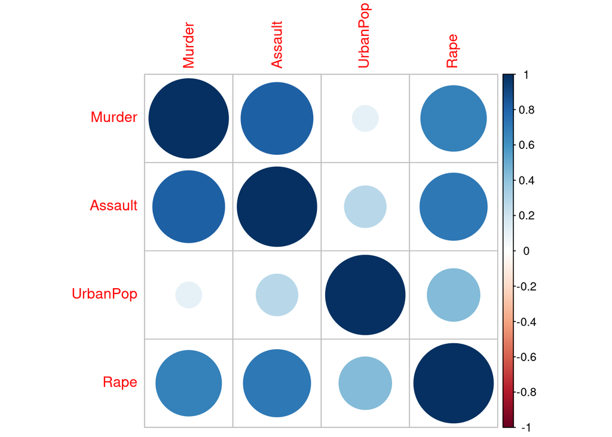

```r
library(corrplot)
a <- cor(USArrests, method = "spearman")
corrplot(a, method="circle")
```

**Exercise**

- b_3 which is a +3
- b_square which is b to the power of 2/ squared
- b_log
- b_complex which is sin(b) * cos(4 * b)

**Solution**

```r
b <- seq(1, 200, 1.5)
b_3 <- b+3
b_square <- b^2
b_log <- log(b)
b_complex <- sin(b) * cos(4 * b)
```

**Exercise**

Plot the relations of b and the above created 4 vectors in a plot with 4 panels. calculate pearson, spearman, and kendall for the four vectors.

**Solution**

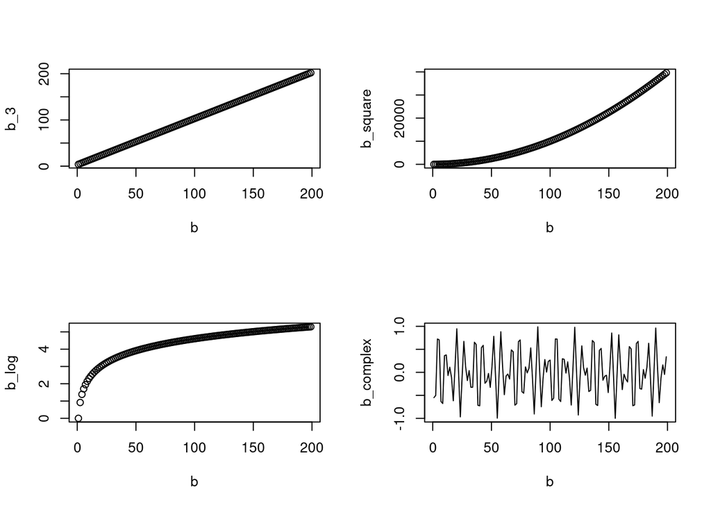

```r
par(mfrow = c(2, 2))
plot(b, b_3)
plot(b, b_square)
plot(b, b_log)
plot(b, b_complex, type = "l")
```

Pearson

```r
cor(tibble(b, b_3, b_square, b_log, b_complex), method = "pearson") |>  round(2)
```

```
             b  b_3 b_square b_log b_complex
b         1.00 1.00     0.97  0.88      0.01
b_3       1.00 1.00     0.97  0.88      0.01
b_square  0.97 0.97     1.00  0.76      0.01
b_log     0.88 0.88     0.76  1.00      0.03
b_complex 0.01 0.01     0.01  0.03      1.00
```

Spearman

```r
cor(tibble(b, b_3, b_square, b_log, b_complex), method = "spearman") |>  round(2)
```

```
             b  b_3 b_square b_log b_complex
b         1.00 1.00     1.00  1.00      0.01
b_3       1.00 1.00     1.00  1.00      0.01
b_square  1.00 1.00     1.00  1.00      0.01
b_log     1.00 1.00     1.00  1.00      0.01
b_complex 0.01 0.01     0.01  0.01      1.00
```

Kendall

```r
cor(tibble(b, b_3, b_square, b_log, b_complex), method = "kendall") |>  round(2)
```

```
             b  b_3 b_square b_log b_complex
b         1.00 1.00     1.00  1.00      0.01
b_3       1.00 1.00     1.00  1.00      0.01
b_square  1.00 1.00     1.00  1.00      0.01
b_log     1.00 1.00     1.00  1.00      0.01
b_complex 0.01 0.01     0.01  0.01      1.00
```

**Exercise**

Calculate the means of the variables from the iris data package by species and visualize with bar plots.

**Solution**

```r
install.packages("ggpubr")
```

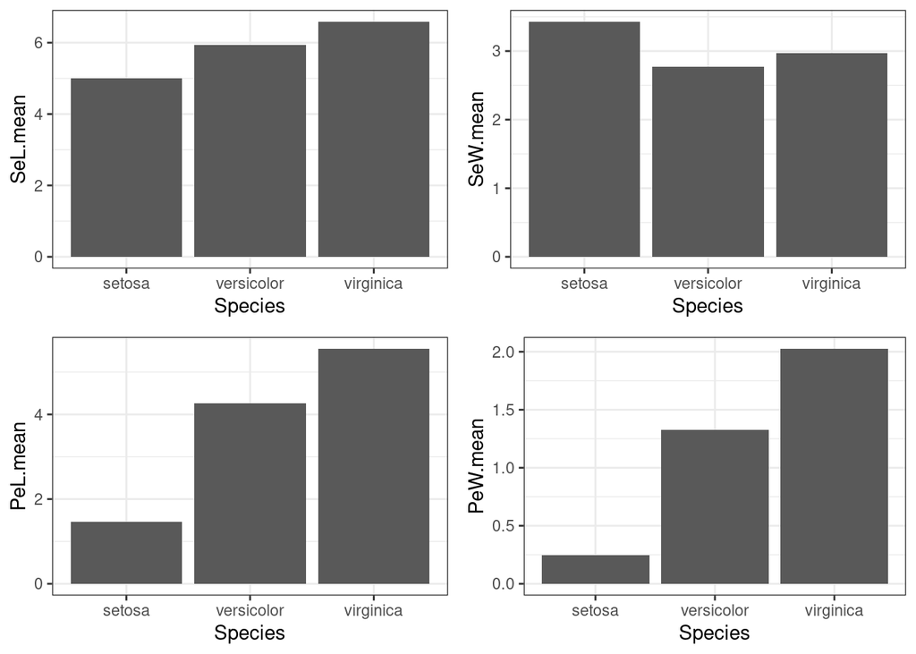

```r
library(tidyverse)
library(ggplot2)
library(ggpubr)
iris_sub <- iris %>%
  group_by(Species) %>%
  summarise(SeL.mean=mean(Sepal.Length),SeW.mean=mean(Sepal.Width),
            PeL.mean=mean(Petal.Length),PeW.mean=mean(Petal.Width))

ggarrange(
  ggplot(data=iris_sub)+
    geom_bar(aes(x=Species,y=SeL.mean), stat="identity")+
    theme_bw(),
  ggplot(data=iris_sub)+
    geom_bar(aes(x=Species,y=SeW.mean), stat="identity")+
    theme_bw(),
  ggplot(data=iris_sub)+
    geom_bar(aes(x=Species,y=PeL.mean), stat="identity")+
    theme_bw(),
  ggplot(data=iris_sub)+
    geom_bar(aes(x=Species,y=PeW.mean),
             stat="identity")+
    theme_bw()
)
```

Note that the `ggpubr` creates “publication-ready” plots from ggplots. It is used to arrange the 4 plots on one panel.

Another solution would be to plot individually, using :

```r
ggplot(data=iris_sub)+
  geom_bar(aes(x=Species,y=SeL.mean), stat="identity")+
  theme_bw()

ggplot(data=iris_sub)+
  geom_bar(aes(x=Species,y=SeW.mean), stat="identity")+
  theme_bw()

ggplot(data=iris_sub)+
  geom_bar(aes(x=Species,y=PeL.mean), stat="identity")+
  theme_bw()

ggplot(data=iris_sub)+
  geom_bar(aes(x=Species,y=PeW.mean),
           stat="identity")+
  theme_bw()
```

**Exercise**

**Solution**

**Exercise**

**Solution**

**Exercise**

**Solution**

**Exercise**

**Solution**

# Repetition of Module 4

## Checkpoint 4.1

**Exercise**

Load the dataset iris and set the rownames as a continues species name.

**Solution**

```r
?iris
iris
```

```
    Sepal.Length Sepal.Width Petal.Length Petal.Width    Species
1            5.1         3.5          1.4         0.2     setosa
2            4.9         3.0          1.4         0.2     setosa
3            4.7         3.2          1.3         0.2     setosa
4            4.6         3.1          1.5         0.2     setosa
5            5.0         3.6          1.4         0.2     setosa
6            5.4         3.9          1.7         0.4     setosa
7            4.6         3.4          1.4         0.3     setosa
8            5.0         3.4          1.5         0.2     setosa
9            4.4         2.9          1.4         0.2     setosa
10           4.9         3.1          1.5         0.1     setosa
11           5.4         3.7          1.5         0.2     setosa
12           4.8         3.4          1.6         0.2     setosa
13           4.8         3.0          1.4         0.1     setosa
14           4.3         3.0          1.1         0.1     setosa
```

[output cut: 136 more lines]

```r
iris <- tibble(Species = paste("species", seq(1, 150), sep = ""),
                      Sepal.Length = sample(c(4:8), 150, replace = T),
                      Sepal.Width = sample(c(2:5), 150, replace = T),
                      Petal.Length = sample(c(1:7), 150, replace = T),
                      Petal.Width = sample (c(0:3), 150, replace= T))
rownames(iris) <- iris |> pull(Species)
```

Note that on newer versions, tibbles can not get row names.

Instead, you can use data.frames :

```r
iris <- data.frame(Species = paste("species", seq(1, 150), sep = ""),
                      Sepal.Length = sample(c(4:8), 150, replace = T),
                      Sepal.Width = sample(c(2:5), 150, replace = T),
                      Petal.Length = sample(c(1:7), 150, replace = T),
                      Petal.Width = sample (c(0:3), 150, replace= T))
rownames(iris) <- iris |> pull(Species)
head(iris)
```

```
          Species Sepal.Length Sepal.Width Petal.Length Petal.Width
species1 species1            4           2            5           2
species2 species2            5           3            3           3
species3 species3            8           4            7           0
species4 species4            7           4            3           0
species5 species5            5           4            7           1
species6 species6            6           5            2           0
```

## Checkpoint 4.2

**Exercise**

Check the data naming below taken from a hypothetical folder. How could you organise this more cleanly?

dataNEW28Aug.xlxs dataCurrent29Aug.csv Scriptforcourse.R Outline.doc UPTODATEScriptforcourse29Aug.R

**Solution**

data_2023_08_28.csv data_2023_08_29.csv course_script_NA.R course_script_2023_08_29.R Outline_2023_08_29.txt

**Exercise**

Navigating with relative filepaths. Your Working Directory is currently set in the first folder path. You want to load the data books from the second folder path. How do you go back to the folder with a relative filepath?

1: /users/charliechaplin/R/R_project1/Charlies_scripts 2: /users/charliechaplin/data/data_4_charlie

**Solution**

`read.csv(../../../data/data_4_charlie/books.csv)`

## Checkpoint 4.3

**Exercise**

```r
togo <- tibble(explanatory = sample(c(1:500), 2000, replace = T),
                   group = rep(c("X", "Y"), 1000))
```

**Solution**

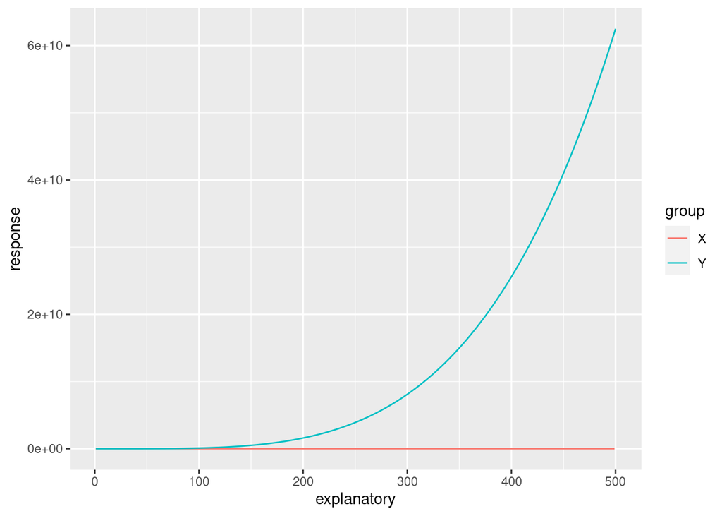

```r
togo <- togo |>
  group_by(group) |>
  mutate(response = case_when(group == "X" ~ explanatory * 3,  group == "Y" ~ explanatory ^4))

library(ggplot2)

ggplot(togo, aes(x = explanatory, y = response, colour = group)) +
  geom_line()
```

**Exercise**

**Solution**

# Outlook

## writing R output

After finishing an analysis or a plot, you certainly want to save some R output.

For plots, you can save via the RStudio Graphical User Interface (GUI) or via code.

### Saving plots via RStudio GUI

1. Create your plot (2) click on “Export” on the top of the graphic panel. Save as image or as pdf. Note that you can select the output size. For PDF, select e.g. A5 landscape or A4, or the “device size” (the size your plot has on the graphic panel). For images, select the desired type, e.g. SVG for a vectorised image (which is not pixeled), or png for a pixel image. The with and height can be given manually as numbers, or manually be changing the preview size.

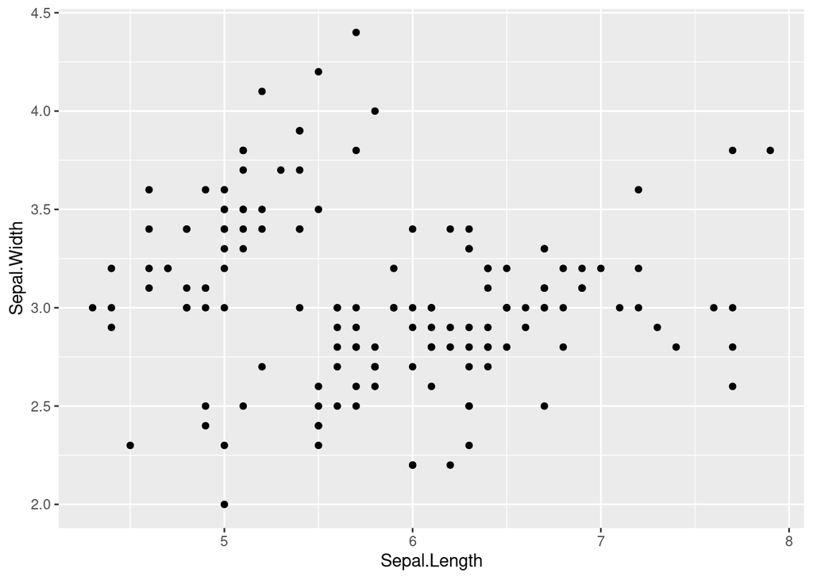

```r
library(ggplot2)
data(iris)
plot_iris <- ggplot(iris, aes(x = Sepal.Length, y = Sepal.Width)) +
  geom_point()
plot_iris
```

**Saving with code**

### Saving plots using the `ggplot2` package

Save **as png**

```r
ggsave(plot_iris,
       filename = "plot_iris_sepallength_sepalwidth.png",
       device = "png",
       width = 20, height = 20, units = "cm",
       dpi = 300)
```

Note that you can adjust the size of the image by setting width and height, e.g. in “cm”. You can also chose inches “in” or pixels “px”.

Further, you can set the image resolution in dpi (dots per inch). Often, journals require 300 dpi. Note that an image of 300 dpi quality takes up more memory than a usual R plot. The image quality suitable for showing on a screen is 72 dpi.

Save **as pdf**

```r
ggsave(plot = plot_iris,
       filename = "plot_iris_sepallength_sepalwidth.pdf",
       device = "pdf",
       width = 14.8, height = 21, units = "cm")
```

By using the with and height in cm arguments, you can e.g. write to an A5 format by specifying 14.8 cm width and 21 cm height which is the size of A5. Look up other paper formats if needed.

### Recommended : Saving plots using the `cowplot` package

The `cowplot` package is a very useful plotting package. It not only allows you to print your plots easily to files, but it also helps you arranging then on a panel.

```r
# install.packages("cowplot")
library(cowplot)
```

Saving a plot as png, tiff or pdf

```r
save_plot(plot = plot_iris,
          base_width = 14.8, base_height = 14.8, units = "cm",
          filename = "plot_iris_sepallength_sepalwidth.png",
          dpi = 72)

save_plot(plot = plot_iris,
          base_width = 14.8, base_height = 14.8, units = "cm",
          filename = "plot_iris_sepallength_sepalwidth.tiff",
          dpi = 72)

save_plot(plot = plot_iris,
          base_width = 14.8, base_height = 21, units = "cm",
          filename = "plot_iris_sepallength_sepalwidth.pdf")
```

#### various plots in one panel

Not only for saving is the `cowplot` package handy, but also to combine and label multiple plots on one panel. [This tutorial](https://cran.r-project.org/web/packages/cowplot/vignettes/introduction.html) gives an introduction, here you get a first impression:

```r
hist_sepallength <- ggplot(iris, aes(x = Sepal.Length)) +
  geom_histogram() +
  theme_half_open() # note that some people prefer a white background

hist_sepalwidth <- ggplot(iris, aes(x = Sepal.Width)) +
  geom_histogram() +
  theme_half_open()

lineplot_iris <- ggplot(iris, aes(x = Sepal.Length, y = Sepal.Width)) +
  geom_point() +
  theme_half_open()
```

Gives you 3 individual plots.

Combine them on one panel by :

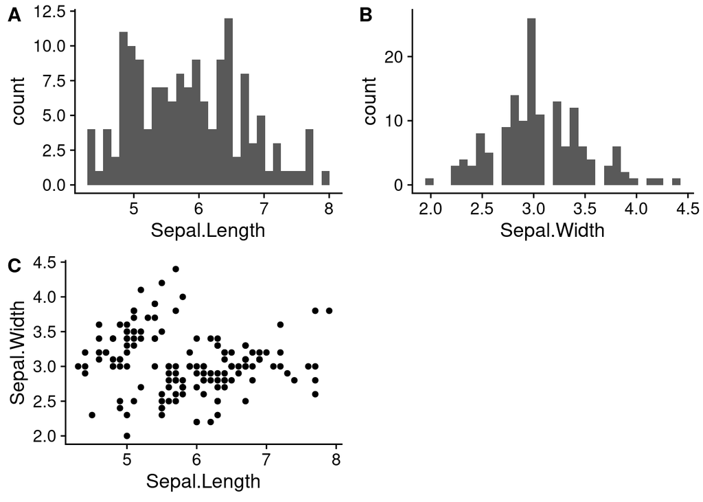

```r
plot_grid(hist_sepallength, hist_sepalwidth, lineplot_iris,
          nrow = 2,
          labels = c("A", "B", "C"))
```

You can even combine plots which are already combined :

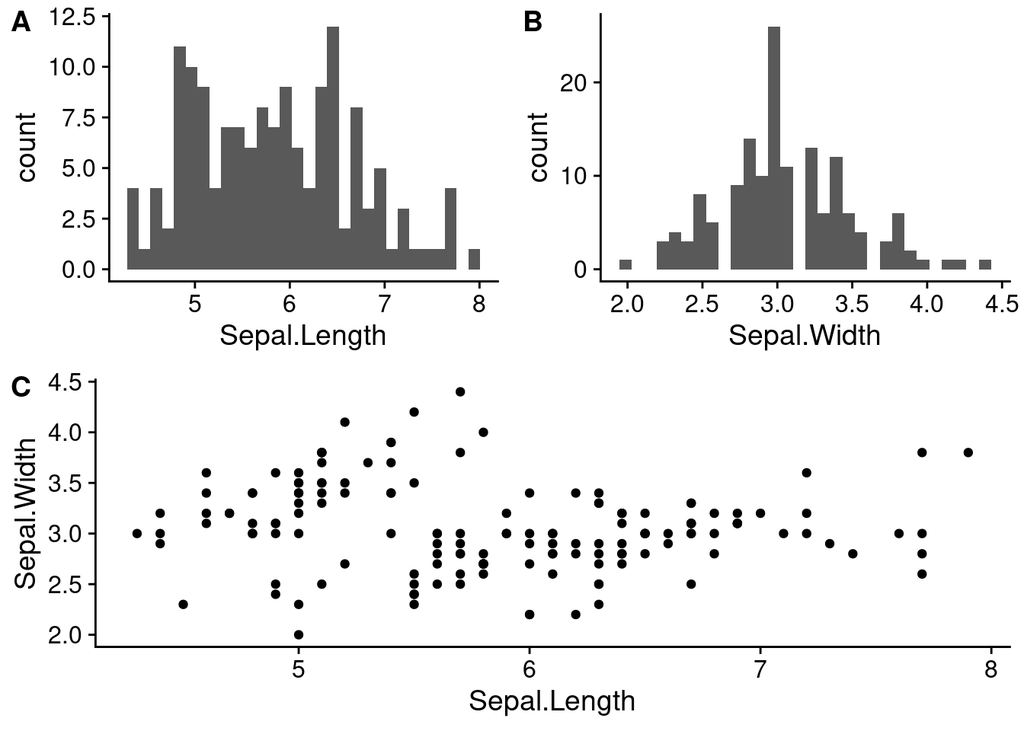

```r
iris_histograms <- plot_grid(hist_sepallength, hist_sepalwidth,
          ncol = 2,
          labels = c("A", "B", "C"))
plot_grid(iris_histograms, lineplot_iris,
          nrow = 2,
          labels = c("", "C"))
```

As always, make sure you label the axes well with names and units (this is a bad example in this aspect).

### Writing datasets with Rbase (recommended)

```r
data(iris)
```

If you want to extract the iris dataset to a file on your computer, the functions look a bit similar than the reading functions.

`write.csv` and `write.csv2` write csv files, either comma “,” or semicolon “;” separated. These functions contains some unhandy default settings: We recommend specifying the `quote` argument to `FALSE`, to prevent quoting of all values in the output table. We also recommend setting the `row.names` argument to `FALSE`, to prevent printing a column of row numbers. Try out playing with those settings to find out exactly what they do. Remember to open the data files with your text editor to see exactly what happens. To just look at the values, you can open with Excel.

```r
# comma-separated ","
write.csv(x = iris, file = "iris.csv",
          quote = F,
          row.names = F)

# semicolon-separated ";"
write.csv2(x = iris, file = "iris.csv",
          quote = F,
          row.names = F)
```

You can use the more generic `write.table` function, and set the separator yourself :

```r
write.table(x = iris, file = "iris.csv",
            sep = ",",
            quote = F,
            row.names = F)
```

Using `sep = ","` writes a comma-separated file, using `sep = ";"` creates a semicolon-separated file. You can also use other separators, e.g. tab by setting `sep = "\t"`

#### Writing intermediate data

R has two internal data formats, which you can use : `.RData` and `.RDS`. Both of these file types are R-specific. While `.RDS` files are used to store single R objects, `.RData` files can save multiple objects. If you use those files a lot, you might want to read more about their differences. For now, I recommend using `.RDS` files because they ease a reproducible workflow (they can be assigned to a new names when reading in, see [D.4.1 Saving R Files in this book](https://rstudio-education.github.io/hopr/dataio.html)).

You can save a file using `saveRDS()` and read a .RDS file using `readRDS`.

```r
saveRDS(object = iris, file = "iris.RDS")
rm(iris) # remove the iris object
iris <- readRDS("iris.RDS")
```

Note that .RDS files are not readable with Excel or Text editors, but only with R. Why should you then bother to create .RDS files? You might consider 2 reasons (amongst others)

- 1. You can save the type of data in .RDS files, not just the values itself. If you save a tibble as .RDS, it is still a tibble when you read it in. If you save a matrix as .RDS file, it is still a matrix when you read it in.
- 2. Probably your R script generates different types of output. Some things, you might want to save for your manuscript. Other output might just be intermediate output, which is not in table format, as e.g. the output of many statistical modelling functions. You might want to save this output as a backup, and here .RDS files are useful. In this way, you can also clearly distinguish between intermediat output (.RDS) and “final output” (.csv and .pdf/.png).